# EasyVisa Project

## Boosting Processes:

- AdaBoost Process includes creating an AdaBoost Model with default parameters and then tuning the model with hyperparameters provided in the project notebook.
- Gradient Boost Process includes creating a Gradient Boost Model with default parameters and then tuning the Model with hyperparameters provided in the project notebook.
- XGBoost Process includes creating a XGBoost Model with default parameters and then tuning the Model with hyperparameters provided in the project notebook.
- Stacking Process includes creating a Stacked Model with previous boosting models with strong scores.

### AdaBoost Model Process

```python
#vanilla ab classifier model
ab_classifier = AdaBoostClassifier(random_state=1)
ab_classifier.fit(X_train,y_train)
```

```
AdaBoostClassifier(random_state=1)
```

```python
#check AB performance train
ab_train_perf = model_performance_classification_sklearn(ab_classifier, X_train, y_train)
ab_train_perf
```

|  | Accuracy | Recall | Precision | F1 |
| --- | --- | --- | --- | --- |
| 0 | 0.737273 | 0.889197 | 0.758865 | 0.818878 |

```python
#check AB performance test
ab_test_perf = model_performance_classification_sklearn(ab_classifier, X_test, y_test)
ab_test_perf
```

|  | Accuracy | Recall | Precision | F1 |
| --- | --- | --- | --- | --- |
| 0 | 0.732862 | 0.885211 | 0.756318 | 0.815704 |

The train and test performances are quite comparable. This model does not heavily overfit the data. Our f1_score on the Test set is 81%. This is similar to the Tuned Random Forest. We can work with hyperparameter tuning to see if this metric can be improved.

```python
# tune the ab classifier
ab_tuned = AdaBoostClassifier(random_state=1)

# Grid of parameters to choose from
param_grid = {
    "n_estimators": np.arange(50,110,25),
    "learning_rate": [0.01,0.1,0.05],
    "base_estimator": [
        DecisionTreeClassifier(max_depth=2, random_state=1),
        DecisionTreeClassifier(max_depth=3, random_state=1),
    ],
}

# Type of scoring used to compare parameter combinations
scorer = metrics.make_scorer(metrics.f1_score)

# Run the grid search
grid_obj = GridSearchCV(ab_tuned, param_grid, scoring=scorer,cv=5)
grid_obj = grid_obj.fit(X_train, y_train)

# Set the clf to the best combination of parameters
ab_tuned = grid_obj.best_estimator_

# Fit the best algorithm to the data.
ab_tuned.fit(X_train, y_train)
```

```
AdaBoostClassifier(base_estimator=DecisionTreeClassifier(max_depth=3,
                                                         random_state=1),
                   learning_rate=0.05, n_estimators=100, random_state=1)
```

```python
#check tuned AB performance train
ab_tuned_train_perf = model_performance_classification_sklearn(ab_tuned, X_train, y_train)
ab_tuned_train_perf
```

|  | Accuracy | Recall | Precision | F1 |
| --- | --- | --- | --- | --- |
| 0 | 0.753252 | 0.883992 | 0.777196 | 0.827161 |

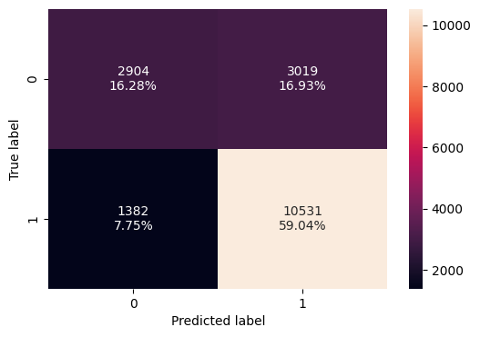

```python
#check confusion matrix tuned AB train
confusion_matrix_sklearn(ab_tuned, X_train, y_train)
```

```python
#check tuned AB performance test
ab_tuned_test_perf = model_performance_classification_sklearn(ab_tuned, X_test, y_test)
ab_tuned_test_perf
```

|  | Accuracy | Recall | Precision | F1 |
| --- | --- | --- | --- | --- |
| 0 | 0.742674 | 0.878159 | 0.769218 | 0.820086 |

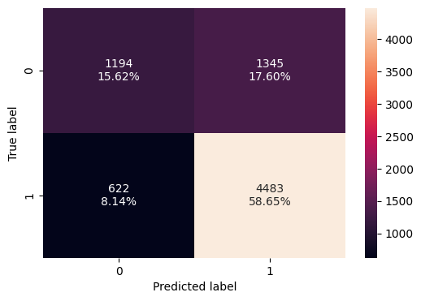

```python
#check confusion matrix tuned AB test
confusion_matrix_sklearn(ab_tuned, X_test, y_test)
```

Comments to compare Default AdaBoost to Tuned AdaBoost: Both AdaBoost models work well on unseen data and do not suffer from overfitting. The Tuned AdaBoost shows a higher F1_Score when compared to the Default Model. Default Train improved from .818 to .827 (tuned) and Default Test improved from .815 to .820 (tuned). **The Tuned AdaBoost Model has provided the highest F1_Score seen thus far.**

### Gradient Boost Process

```python
#vanilla gradient boost model
gb = GradientBoostingClassifier(random_state=1)
gb.fit(X_train,y_train)
```

```
GradientBoostingClassifier(random_state=1)
```

```python
#check performance on GB train
gb_train_perf = model_performance_classification_sklearn(gb, X_train, y_train)
gb_train_perf
```

|  | Accuracy | Recall | Precision | F1 |
| --- | --- | --- | --- | --- |
| 0 | 0.75841 | 0.883657 | 0.782677 | 0.830107 |

```python
#check performance on GB test
gb_test_perf = model_performance_classification_sklearn(gb, X_test, y_test)
gb_test_perf
```

|  | Accuracy | Recall | Precision | F1 |
| --- | --- | --- | --- | --- |
| 0 | 0.745683 | 0.876983 | 0.772829 | 0.821619 |

The performance metrics of the train and test sets are similar, with a small decrease in f1_score (Train 83% test 82%). These metrics are similar to our Tuned AdaBoost Model. We will try to make improvements by testing different hyperparameters.

```python
#tune the GB model
gb_tuned = GradientBoostingClassifier(random_state=1)

# Grid of parameters to choose from
param_grid = {
    "init": [AdaBoostClassifier(random_state=1),DecisionTreeClassifier(random_state=1)],
    "n_estimators": np.arange(50,110,25),
    "learning_rate": [0.01,0.1,0.05],
    "subsample":[0.7,0.9],
    "max_features":[0.5,0.7,1],
}

# Type of scoring used to compare parameter combinations
scorer = metrics.make_scorer(metrics.f1_score)

# Run the grid search
grid_obj = GridSearchCV(gb_tuned, param_grid, scoring=scorer,cv=5)
grid_obj.fit(X_train, y_train)

# Set the clf to the best combination of parameters
gb_tuned = grid_obj.best_estimator_

# Fit the best algorithm to the data.
gb_tuned.fit(X_train, y_train)
```

```
GradientBoostingClassifier(init=AdaBoostClassifier(random_state=1),
                           max_features=0.5, n_estimators=50, random_state=1,
                           subsample=0.9)
```

```python
#check tuned GB performance train
gb_tuned_train_perf = model_performance_classification_sklearn(gb_tuned, X_train, y_train)
gb_tuned_train_perf
```

|  | Accuracy | Recall | Precision | F1 |
| --- | --- | --- | --- | --- |
| 0 | 0.752691 | 0.876438 | 0.780344 | 0.825604 |

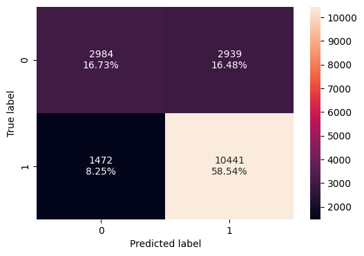

```python
#check confusion matrix tuned GB train
confusion_matrix_sklearn(gb_tuned, X_train, y_train)
```

```python
#check tuned GB performance test
gb_tuned_test_perf = model_performance_classification_sklearn(gb_tuned, X_test, y_test)
gb_tuned_test_perf
```

|  | Accuracy | Recall | Precision | F1 |
| --- | --- | --- | --- | --- |
| 0 | 0.743982 | 0.87189 | 0.773549 | 0.819781 |

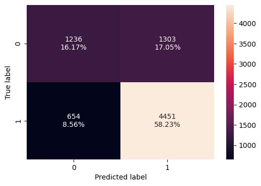

```python
#check confusion matrix tuned GB test
confusion_matrix_sklearn(gb_tuned, X_test, y_test)
```

Comments to compare Default Gradient Boost Model and Tuned Gradient Boost Model: The performance metrics of the two models have very little difference. Neither the Default or Tuned Gradient Boost Classifiers suffer from overfitting; they both perform well on unseen data. The Test metrics of the Default GB are higher than the Test metrics on the Tuned GB. Example: Default Test f1_score = .821 and Tuned Test f1_score = .819. If we had to choose between the two models, the Default Gradient Boost is the better option as it has a better balance between recall and precision. This f1_score is also an improvement on the Tuned AdaBoost model's f1_score.

### XGBoost Process

```python
#vanilla XGB model
xgb = XGBClassifier(random_state=1, eval_metrics='logloss')
xgb.fit(X_train,y_train)
```

```
XGBClassifier(base_score=None, booster=None, callbacks=None,
              colsample_bylevel=None, colsample_bynode=None,
              colsample_bytree=None, device=None, early_stopping_rounds=None,
              enable_categorical=False, eval_metric=None,
              eval_metrics='logloss', feature_types=None, gamma=None,
              grow_policy=None, importance_type=None,
              interaction_constraints=None, learning_rate=None, max_bin=None,
              max_cat_threshold=None, max_cat_to_onehot=None,
              max_delta_step=None, max_depth=None, max_leaves=None,
              min_child_weight=None, missing=nan, monotone_constraints=None,
              multi_strategy=None, n_estimators=None, n_jobs=None,
              num_parallel_tree=None, ...)
```

```python
#check performance on XGB train
xgb_train_perf = model_performance_classification_sklearn(xgb, X_train, y_train)
xgb_train_perf
```

|  | Accuracy | Recall | Precision | F1 |
| --- | --- | --- | --- | --- |
| 0 | 0.84122 | 0.928146 | 0.848385 | 0.886475 |

```python
#check performance on XGB test
xgb_test_perf = model_performance_classification_sklearn(xgb, X_test, y_test)
xgb_test_perf
```

|  | Accuracy | Recall | Precision | F1 |
| --- | --- | --- | --- | --- |
| 0 | 0.728676 | 0.851714 | 0.76752 | 0.807428 |

The performance metrics on the default XGBoost model are comparable to the Gradient Boost scores. We do see that, with an f1_score of 88% on train data and 80% on test data, the model does decrease in performance. We will try to improve our performance metrics by working with the provided hyperparameters to tune the model.

```python
# Choose the type of classifier.
xgb_tuned = XGBClassifier(random_state=1, eval_metric='logloss')

# Grid of parameters to choose from
param_grid={'n_estimators':np.arange(50,110,25),
            'scale_pos_weight':[1,2,5],
            'learning_rate':[0.01,0.1,0.05],
            'gamma':[1,3],
            'subsample':[0.7,0.9]
}

# Type of scoring used to compare parameter combinations
scorer = metrics.make_scorer(metrics.f1_score)

# Run the grid search
grid_obj = GridSearchCV(xgb_tuned, param_grid, scoring=scorer,cv=5)
grid_obj = grid_obj.fit(X_train, y_train)

# Set the clf to the best combination of parameters
xgb_tuned = grid_obj.best_estimator_

# Fit the best algorithm to the data.
xgb_tuned.fit(X_train, y_train)
```

```
XGBClassifier(base_score=None, booster=None, callbacks=None,
              colsample_bylevel=None, colsample_bynode=None,
              colsample_bytree=None, device=None, early_stopping_rounds=None,
              enable_categorical=False, eval_metric='logloss',
              feature_types=None, gamma=3, grow_policy=None,
              importance_type=None, interaction_constraints=None,
              learning_rate=0.05, max_bin=None, max_cat_threshold=None,
              max_cat_to_onehot=None, max_delta_step=None, max_depth=None,
              max_leaves=None, min_child_weight=None, missing=nan,
              monotone_constraints=None, multi_strategy=None, n_estimators=50,
              n_jobs=None, num_parallel_tree=None, random_state=1, ...)
```

```python
#check performance on tuned XGB train
xgb_tuned_train_perf = model_performance_classification_sklearn(xgb_tuned, X_train, y_train)
xgb_tuned_train_perf
```

|  | Accuracy | Recall | Precision | F1 |
| --- | --- | --- | --- | --- |
| 0 | 0.761998 | 0.888105 | 0.784168 | 0.832907 |

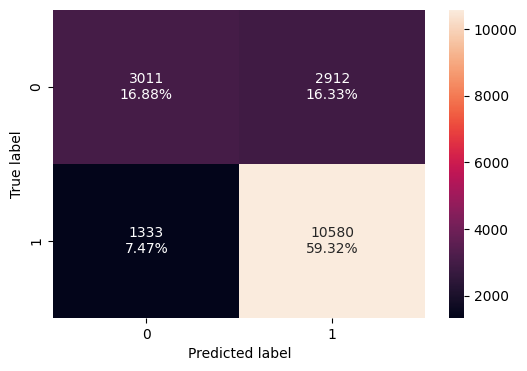

```python
#check confusion matrix tuned XGB train
confusion_matrix_sklearn(xgb_tuned, X_train, y_train)
```

```python
#check performance on tuned XGB test
xgb_tuned_test_perf = model_performance_classification_sklearn(xgb_tuned, X_test, y_test)
xgb_tuned_test_perf
```

|  | Accuracy | Recall | Precision | F1 |
| --- | --- | --- | --- | --- |
| 0 | 0.744244 | 0.877179 | 0.771271 | 0.820823 |

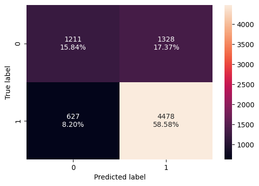

```python
#check confusion matrix tuned XGB test
confusion_matrix_sklearn(xgb_tuned, X_test, y_test)
```

Comments to compare Default XGBoost and Tuned XGBoost performance: The performance metrics on the train sets of the Default XGB are better than the tuned XGB; however, the Train and Test scores are more closely related for the Tuned XGB. The Tuned XGB also outputs a higher f1_score on the test data (.820 or 82%). The tuned model does better on unseen data than the default model.

### Stacking Process

```python
estimators = [('Random Forest',rf_estimator), ('AdaBoost',ab_tuned), ('Gradient Boosting',gb)]

final_estimator = xgb_tuned

stacking_classifier= StackingClassifier(estimators=estimators,final_estimator=final_estimator)

stacking_classifier.fit(X_train,y_train)
```

```
StackingClassifier(estimators=[('Random Forest',
                                RandomForestClassifier(class_weight='balanced',
                                                       max_samples=0.4,
                                                       n_estimators=110,
                                                       oob_score=True,
                                                       random_state=1)),
                               ('AdaBoost',
                                AdaBoostClassifier(base_estimator=DecisionTreeClassifier(max_depth=3,
                                                                                         random_state=1),
                                                   learning_rate=0.05,
                                                   n_estimators=100,
                                                   random_state=1)),
                               ('Gradient Boosting',
                                GradientBoostingClass...
                                                 feature_types=None, gamma=3,
                                                 grow_policy=None,
                                                 importance_type=None,
                                                 interaction_constraints=None,
                                                 learning_rate=0.05,
                                                 max_bin=None,
                                                 max_cat_threshold=None,
                                                 max_cat_to_onehot=None,
                                                 max_delta_step=None,
                                                 max_depth=None,
                                                 max_leaves=None,
                                                 min_child_weight=None,
                                                 missing=nan,
                                                 monotone_constraints=None,
                                                 multi_strategy=None,
                                                 n_estimators=50, n_jobs=None,
                                                 num_parallel_tree=None,
                                                 random_state=1, ...))
```

```python
#check performance on Stacking model train
stacking_train_perf = model_performance_classification_sklearn(stacking_classifier, X_train, y_train)
stacking_train_perf
```

|  | Accuracy | Recall | Precision | F1 |
| --- | --- | --- | --- | --- |
| 0 | 0.782406 | 0.901872 | 0.798454 | 0.847018 |

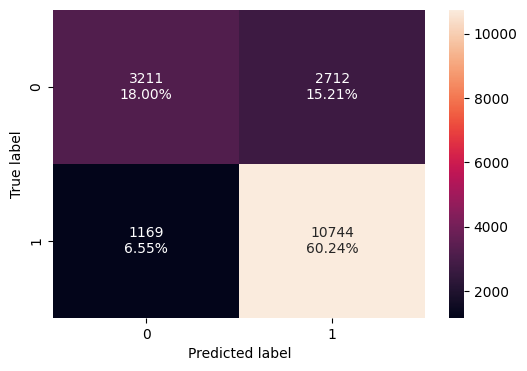

```python
#check confusion matrix Stacking train
confusion_matrix_sklearn(stacking_classifier, X_train, y_train)
```

```python
#check performance on Stacking model test
stacking_test_perf = model_performance_classification_sklearn(stacking_classifier, X_test, y_test)
stacking_test_perf
```

|  | Accuracy | Recall | Precision | F1 |
| --- | --- | --- | --- | --- |
| 0 | 0.743328 | 0.877571 | 0.770156 | 0.820363 |

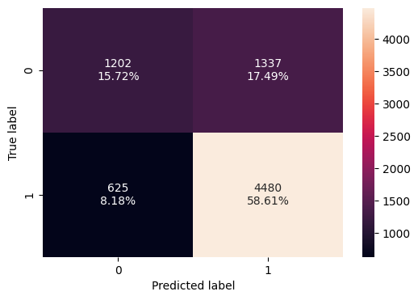

```python
#check confusion matrix Stacking test
confusion_matrix_sklearn(stacking_classifier, X_test, y_test)
```

## Will tuning the hyperparameters improve the model performance?

We see many instances (above) where tuning the models improved the performance metrics.

- Cases where Tuning Improved the Model: Decision Tree, Bagging, Random Forest, AdaBoost, XGBoost.
- The Gradient Boost model did not display improved performance when working with hyperparameters / GridSearchCV. This is why we used the default Gradient Boost model in our Stacking model.

## Model Performance Comparison and Conclusions

```python
#compare training performance of all models
models_train_information = pd.concat([dtree_train_perf.T, dtree_estimator_train_perf.T, bagging_train_perf.T, bagging_tuned_train_perf.T, rf_train_perf.T, rf_estimator_train_perf.T, ab_train_perf.T,
                                      ab_tuned_train_perf.T, gb_train_perf.T, gb_tuned_train_perf.T, xgb_train_perf.T, xgb_tuned_train_perf.T, stacking_train_perf.T], axis=1)
models_train_information.columns = ['Decision Tree', 'Tuned Decision Tree', 'Bagging', 'Tuned Bagging', 'Random Forest', 'Tuned Random Forest', 'AdaBoost', 'Tuned AdaBoost', 'Gradient Boost',
                                    'Tuned Gradient Boost', 'XGBoost', 'Tuned XGBoost', 'Stacking']

#display train performance metrics all models
print('Training Performance Comparisons:')

models_train_information
```

```
Training Performance Comparisons:
```

|  | Decision Tree | Tuned Decision Tree | Bagging | Tuned Bagging | Random Forest | Tuned Random Forest | AdaBoost | Tuned AdaBoost | Gradient Boost | Tuned Gradient Boost | XGBoost | Tuned XGBoost | Stacking |
| --- | --- | --- | --- | --- | --- | --- | --- | --- | --- | --- | --- | --- | --- |
| Accuracy | 1.0 | 0.716641 | 0.983012 | 0.997365 | 1.0 | 0.919152 | 0.737273 | 0.753252 | 0.758410 | 0.752691 | 0.841220 | 0.761998 | 0.782406 |
| Recall | 1.0 | 0.779569 | 0.983463 | 0.999832 | 1.0 | 0.975657 | 0.889197 | 0.883992 | 0.883657 | 0.876438 | 0.928146 | 0.888105 | 0.901872 |
| Precision | 1.0 | 0.792744 | 0.991034 | 0.996236 | 1.0 | 0.909824 | 0.758865 | 0.777196 | 0.782677 | 0.780344 | 0.848385 | 0.784168 | 0.798454 |
| F1 | 1.0 | 0.786101 | 0.987234 | 0.998031 | 1.0 | 0.941591 | 0.818878 | 0.827161 | 0.830107 | 0.825604 | 0.886475 | 0.832907 | 0.847018 |

```python
#xcompare testing performance of all models
models_test_information = pd.concat([dtree_test_perf.T, dtree_estimator_test_perf.T, bagging_test_perf.T, bagging_tuned_test_perf.T, rf_test_perf.T,
                                     rf_estimator_test_perf.T, ab_test_perf.T, ab_tuned_test_perf.T, gb_test_perf.T, gb_tuned_test_perf.T, xgb_test_perf.T, xgb_tuned_test_perf.T, stacking_test_perf.T], axis = 1)
models_test_information.columns = ['Decision Tree', 'Tuned Decision Tree', 'Bagging', 'Tuned Bagging', 'Random Forest', 'Tuned Random Forest', 'AdaBoost', 'Tuned AdaBoost', 'Gradient Boost',
                                    'Tuned Gradient Boost', 'XGBoost', 'Tuned XGBoost', 'Stacking']

#display test performance metrics all models
print('Test Performance Comparisons:')

models_test_information
```

```
Test Performance Comparisons:
```

|  | Decision Tree | Tuned Decision Tree | Bagging | Tuned Bagging | Random Forest | Tuned Random Forest | AdaBoost | Tuned AdaBoost | Gradient Boost | Tuned Gradient Boost | XGBoost | Tuned XGBoost | Stacking |
| --- | --- | --- | --- | --- | --- | --- | --- | --- | --- | --- | --- | --- | --- |
| Accuracy | 0.652276 | 0.715594 | 0.697017 | 0.724882 | 0.723051 | 0.731947 | 0.732862 | 0.742674 | 0.745683 | 0.743982 | 0.728676 | 0.744244 | 0.743328 |
| Recall | 0.748090 | 0.782370 | 0.774731 | 0.865426 | 0.845054 | 0.863859 | 0.885211 | 0.878159 | 0.876983 | 0.871890 | 0.851714 | 0.877179 | 0.877571 |
| Precision | 0.735696 | 0.789796 | 0.772310 | 0.757285 | 0.764894 | 0.765094 | 0.756318 | 0.769218 | 0.772829 | 0.773549 | 0.767520 | 0.771271 | 0.770156 |
| F1 | 0.741841 | 0.786066 | 0.773518 | 0.807752 | 0.802978 | 0.811482 | 0.815704 | 0.820086 | 0.821619 | 0.819781 | 0.807428 | 0.820823 | 0.820363 |

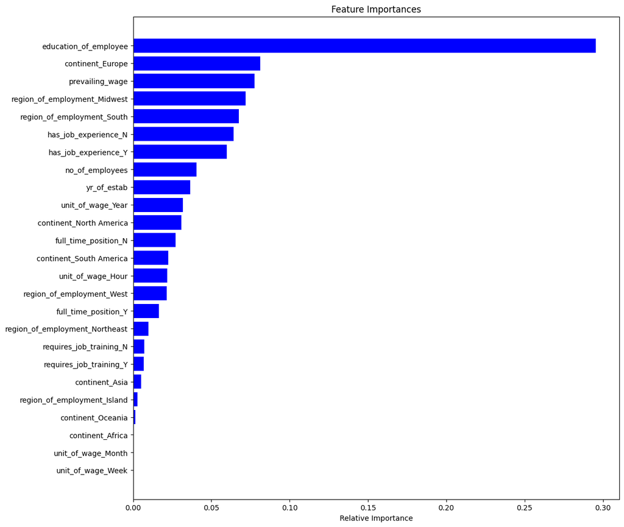

```python
feature_names = X_train.columns
importances = ab_tuned.feature_importances_
indices = np.argsort(importances)

plt.figure(figsize=(12,12))
plt.title('Feature Importances')
plt.barh(range(len(indices)), importances[indices], color='b', align='center')
plt.yticks(range(len(indices)), [feature_names[i] for i in indices])
plt.xlabel('Relative Importance')
plt.show()
```

The 3 most important features in the Tuned AdaBoost model were employee education, employee being from Europe, and the prevailing wage.

## Actionable Insights and Recommendations:

- The feature importances listed above connect well to the observations taken from our EDA section of the notebook. We knew there are a pattern where higher levels of education received more certifications. We also knew that applicants from Europe were more likely to be certified. The model has proven to be useful in better understnading the impacts of wage on the visa status, as our visualization of the bivariate relationship between case status and prevailing wage showed us very similar plots for the two statuses. Our model helps us confirm that higher wages relate to certification.
- A suitable profile of an applicant for whom the visa should be **certified** could be described as: having a Master's or Doctorate degree, originated from Europe, applying for a high-wage job (example: >$75,000-- the approximate median of the data subset), intention to work in the Midwest or Southern regions.
- A suitable profile of an applicant for whom the visa should be **denied** could be described as: having a High School level of education, originated from Africa, applying for a lower-wage job (particularly a job that pays monthly or weekly), intention to work in an Island region.
- While the above descriptions are not exhaustive, the model provides us with the key information that allows us to filter the EasyVisa applications to manage the cumbersome task. -Recommendations: as the number of applications continues to rise, the model gives us insight to transition the approval process into stages. As application profiles come in, the education level can be used to section the applications into high and low priority.
- Note: The model could be very much improved if EasyVisa were given more information regarding the type of work an employee is applying for. While our data gave information about the size of a company and its age, it may be more beneficial to know if the employee is intended to work in a Farming, Banking, Tech, Hospitality, or other industry. This would further help us understand other data attributes such as required job training, full time vs not (example: farming is a seasonal market), and why the unit of wage would be designated as monthly, weekly, etc.